# varioscan analysis

Jurre Hageman

2020-02-21

# Deafault plate setup

A default plate setup is as ahown below:

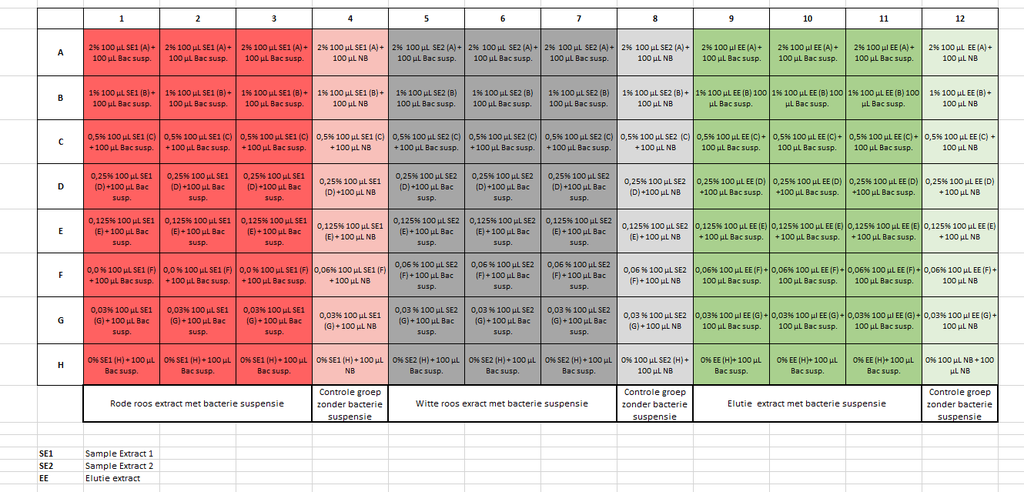

Plate Setup

# User Settings

```r
# Set organism
organism <- "My Organism"

# Set file and folder
filename <- "2020-01-30.csv"
excel_file <- "2020-01-30.xlsx"
folder <- "sample_data"

# Set samples
sample_1 <- "Sample1"
sample_2 <- "Sample2"
sample_3 <- "Elution"

# Set columns (sample#_replicate).
# This is for user input convenience.
# Sample and replicate will be separated later using dplyr::separate
col_1 <- "1_1"
col_2 <- "1_2"
col_3 <- "1_3"
col_4 <- "1_c"
col_5 <- "2_1"
col_6 <- "2_2"
col_7 <- "2_3"
col_8 <- "2_c"
col_9 <- "3_1"
col_10 <- "3_2"
col_11 <- "3_3"
col_12 <- "3_c"

# Set dilutions
row_1 <- 2
row_2 <- 1
row_3 <- 0.5
row_4 <- 0.25
row_5 <- 0.13
row_6 <- 0.06
row_7 <- 0.03
row_8 <- 0

# Set line colors
linecolors <- c("#FF3633", "#FF8933", "#FCFF33", "#62FF33", "#33FFEB", "#33A7FF", "#5F33FF", "#EA33FF")
```

# Imports

```r
library(Rmisc)
library(tidyverse)
```

# Converting user input

```r
samples <- c(sample_1, sample_2, sample_3)
columns <- c("row", col_1, col_2, col_3, col_4, col_5, col_6, col_7, col_8, col_9, col_10, col_11, col_12)
dilution_series <- factor(c(row_1, row_2, row_3, row_4, row_5, row_6, row_7, row_8))
filepath <- file.path(folder, filename)
filepath_excel <- file.path(folder, excel_file)
group1 <- c('1_1', '1_2', '1_3', '1_c')
group2 <- c('2_1', '2_2', '2_3', '2_c')
group3 <- c('3_1', '3_2', '3_3', '3_c')
```

# Loading the data

## Read from Excel in `xlsx` format

```r
library("readxl")
df <- read_excel(filepath_excel, sheet = 2) %>% slice(-1:-1) #drop the first row
```

```
## * `` -> ...1
## * `` -> ...2
## * `` -> ...3
## * `` -> ...4
## * `` -> ...5
## * ...
```

```r
skip <- 14 #each time, 14 rows of plate info that will be skipped
collect <- 8 #there are 8 rows of OD data that I will keep
reps <- nrow(df) %/% (skip + collect) #number of repetitions
index <- rep(0:(reps - 1), each = collect) * (skip + collect) + (1 : collect) + skip
df <- df[index, ] #collect the blocks of OD data
df <- df[, 1:13]
colnames(df) <- columns
df[2:13] <- lapply(df[2:13], function(x) as.numeric(as.character(x)))
df
```

```
## # A tibble: 872 x 13
##    row   `1_1` `1_2` `1_3`  `1_c`  `2_1`  `2_2` `2_3`  `2_c`  `3_1`  `3_2`
##    <chr> <dbl> <dbl> <dbl>  <dbl>  <dbl>  <dbl> <dbl>  <dbl>  <dbl>  <dbl>
##  1 A     0.465 0.400 0.399 0.366  0.131  0.146  0.137 0.118  0.101  0.144
##  2 B     0.321 0.350 0.349 0.328  0.130  0.141  0.138 0.162  0.118  0.109
##  3 C     0.260 0.243 0.236 0.216  0.131  0.135  0.125 0.129  0.0950 0.125
##  4 D     0.172 0.189 0.176 0.164  0.117  0.0998 0.141 0.127  0.101  0.120
##  5 E     0.166 0.169 0.160 0.149  0.128  0.105  0.127 0.113  0.104  0.112
##  6 F     0.138 0.148 0.154 0.141  0.0976 0.113  0.110 0.116  0.109  0.124
##  7 G     0.147 0.131 0.112 0.130  0.104  0.105  0.107 0.0980 0.112  0.113
##  8 H     0.117 0.123 0.104 0.0980 0.0993 0.0974 0.126 0.104  0.106  0.111
##  9 A     0.348 0.263 0.277 0.259  0.101  0.109  0.102 0.0952 0.0825 0.0861
## 10 B     0.267 0.291 0.293 0.270  0.107  0.104  0.109 0.119  0.0850 0.0800
## # ... with 862 more rows, and 2 more variables: `3_3` <dbl>, `3_c` <dbl>
```

## Read from a `csv` file.

```r
# df <- read_csv2(filepath,
#                 col_types = cols(row = 'c', .default = col_double()),
#                 col_names = columns) %>% #Using col_names also removes the empty columns
#   slice(-1:-2) #drop the first two rows
#
# skip <- 14 #each time, 14 rows of plate info that will be skipped
# collect <- 8 #there are 8 rows of OD data that I will keep
# reps <- nrow(df) %/% (skip + collect) #number of repetitions
# index <- rep(0:(reps - 1), each = collect) * (skip + collect) + (1 : collect) + skip
# df <- df[index, ] #collect the blocks of OD data
# df
```

# Add timepoint and dillution columns

```r
num_of_timepoints <- nrow(df) / 8 - 1
timepoints_actual <- seq(0, (10 * num_of_timepoints), by = 10)
timepoints <- rep(timepoints_actual, each = 8)
dilutions <- rep(dilution_series, times = num_of_timepoints + 1)

df <- mutate(df, timepoint = timepoints, dilution = dilutions) %>%
  select(1, timepoint, dilution, everything())
#View(df)
```

# Make tidy

```r
#Use dplyr to make tidy df tables
#Need to gather at multiple levels, hence the function.
generateTidy <- function(df_t, selector){
  df_t <- df_t %>%
    select(row, timepoint, dilution, all_of(selector)) %>%
    gather(selector[1], selector[2], selector[3], key = 'sample', value = 'OD_S') %>%
    separate(sample, into = c('sample', 'replicate')) %>%
    select(1:3, sample, replicate, 'OD_S', selector[4]) %>%
    dplyr::rename('OD_C' = selector[4]) %>%
    mutate(OD_N = OD_S - OD_C)
  return(df_t)
}

df_tidy_s1 <- generateTidy(df, group1)
df_tidy_s2 <- generateTidy(df, group2)
df_tidy_s3 <- generateTidy(df, group3)
#View(df_tidy_s1)
```

# Summary Data

```r
#Use the summarySE package to calculate the mean, SD, SE and CI data at once.
vars <- c("dilution", "timepoint")
stat.sample1 <- summarySE(df_tidy_s1, measurevar="OD_N", groupvars=vars)
stat.sample2 <- summarySE(df_tidy_s2, measurevar="OD_N", groupvars=vars)
stat.sample3 <- summarySE(df_tidy_s3, measurevar="OD_N", groupvars=vars)
#View(stat.sample3)
```

# Generate Plots

## Plot 1

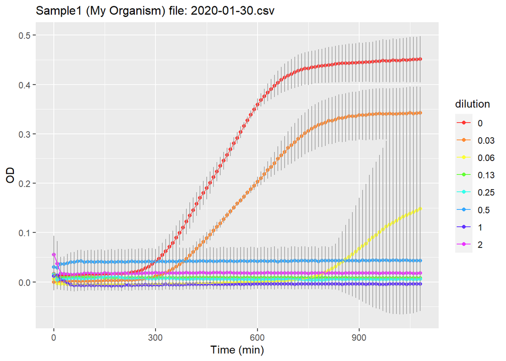

## Plot 2

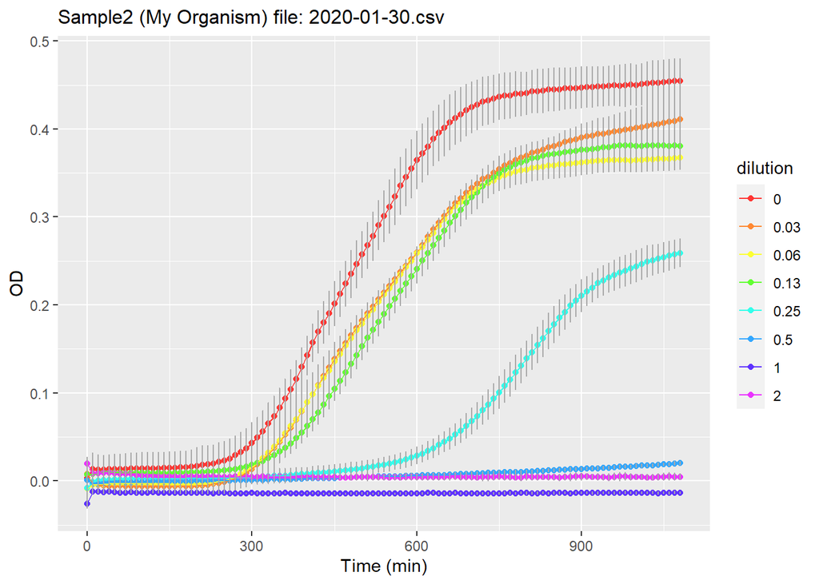

## Plot 3

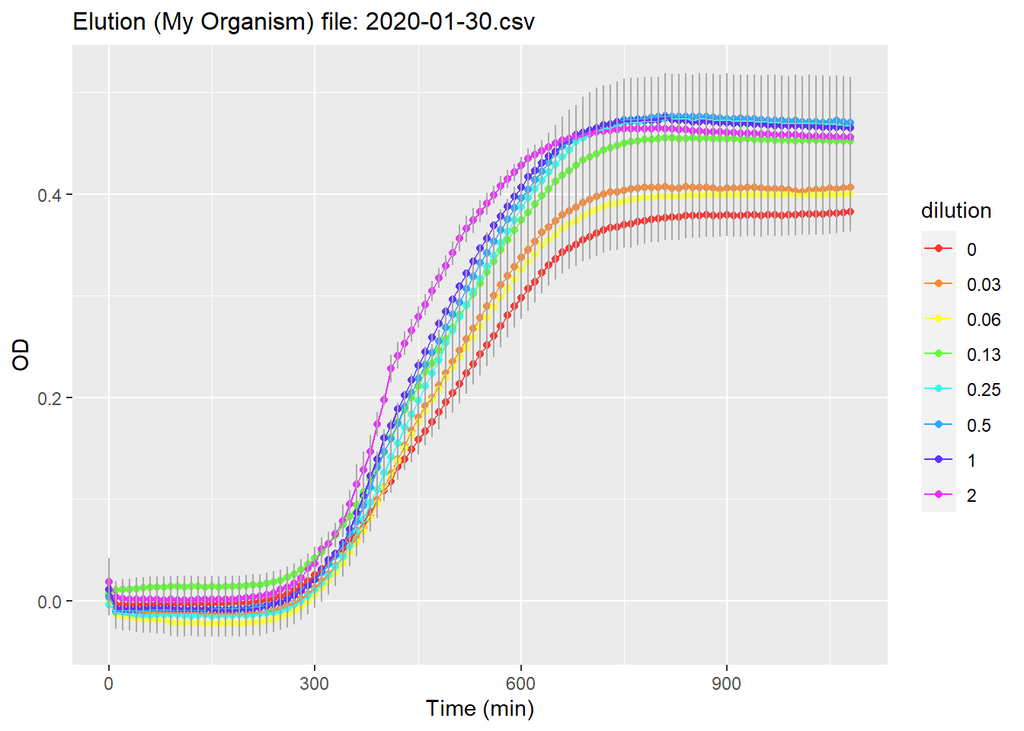

# Controls (can be used to find a contamination)

```r
generatePlotControl <- function(sample, title.string){
  ggplot(data=sample, mapping = aes(x = timepoint, y = OD_C, group = dilution)) +
  geom_point(aes(color = dilution)) +
  geom_line(aes(color = dilution)) +
  scale_color_manual(values = linecolors) +
  labs(x = "Time (min)", y = "OD", title = paste("Control:", title.string, sep = " ")) +
    ylim(0, 0.5) +
    theme(plot.title = element_text(size=12))
}
```

## Plot 1

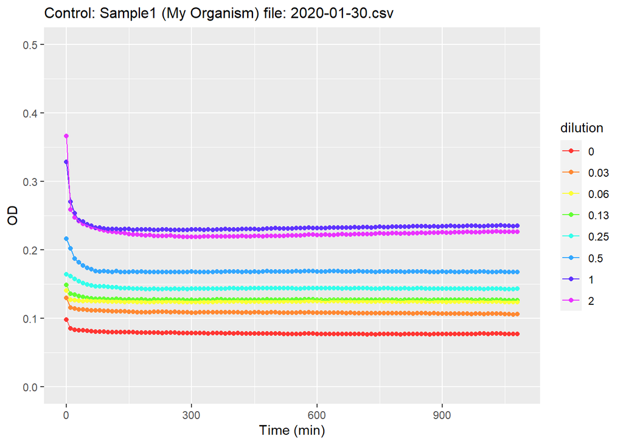

## Plot 2

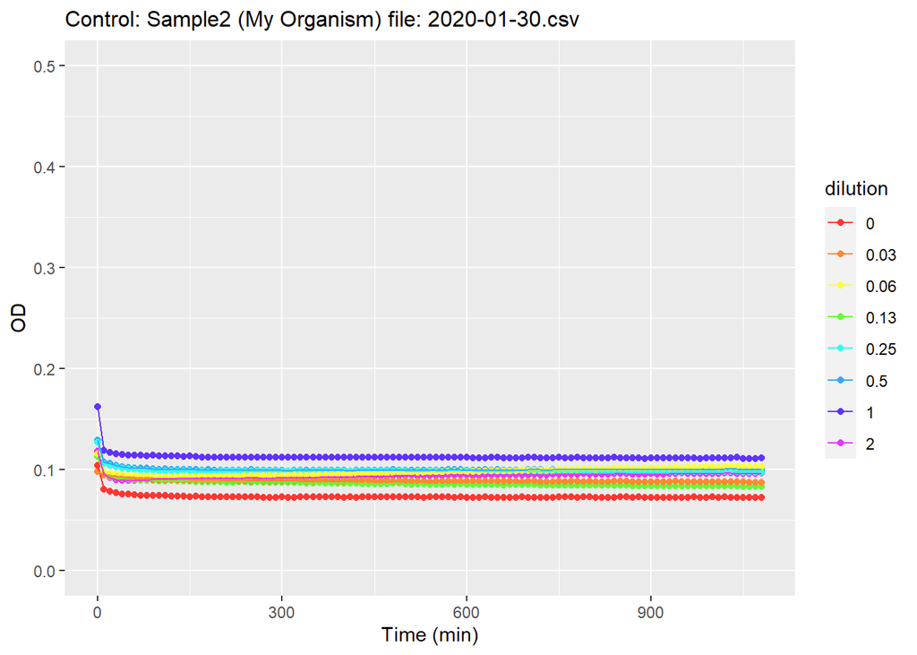

## Plot 3

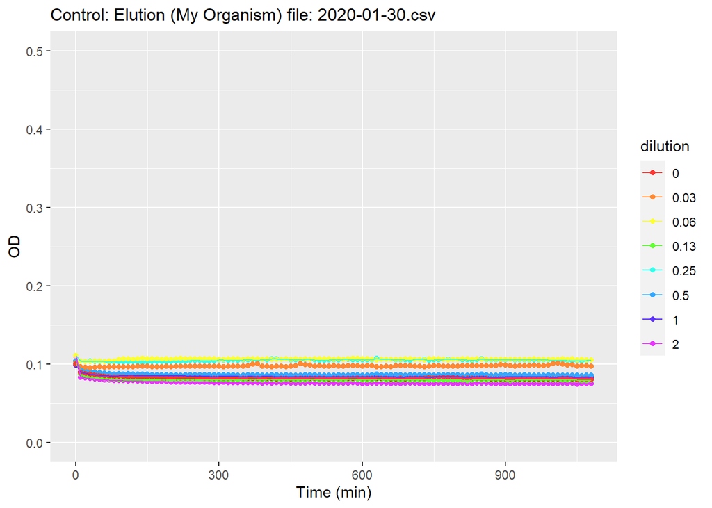

# Each data series separate (can be used to find a contamination)

```r
generatePlotEachLine <- function(sample, title.string){
  ggplot(data=sample, mapping = aes(x = timepoint, y = OD_N, group = dilution)) +
  geom_point(aes(color = dilution)) +
  scale_color_manual(values = linecolors) +
  labs(x = "Time (min)", y = "OD", title = paste("Each sample separate:", title.string, sep = " ")) +
    theme(plot.title = element_text(size=12))
}
```

## Plot 1

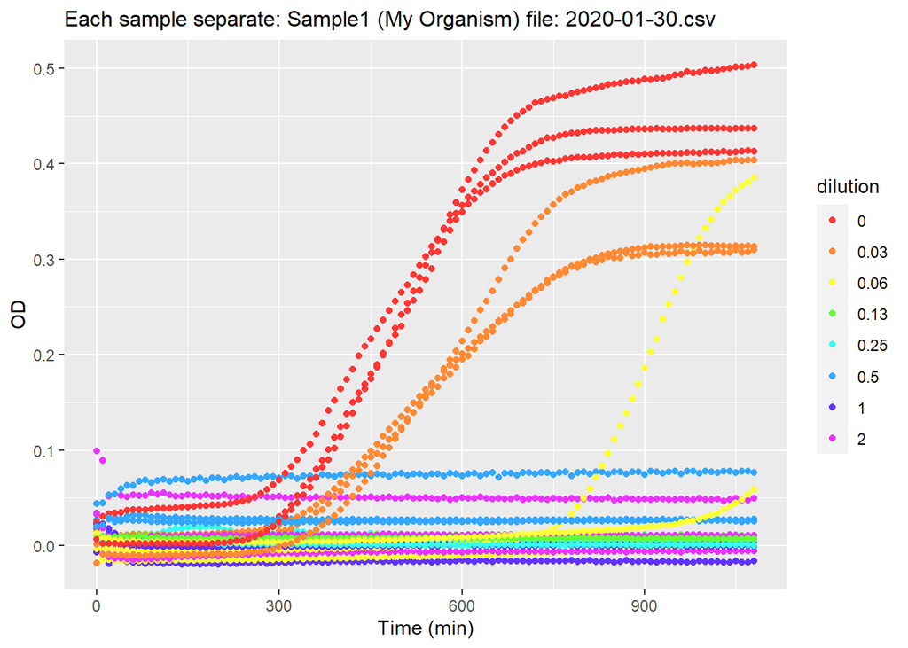

## Plot 2

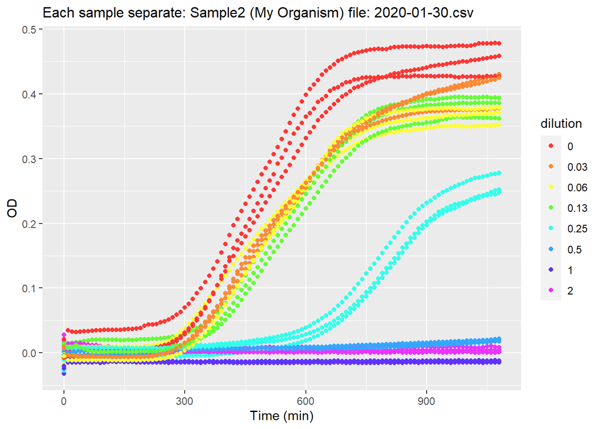

## Plot3

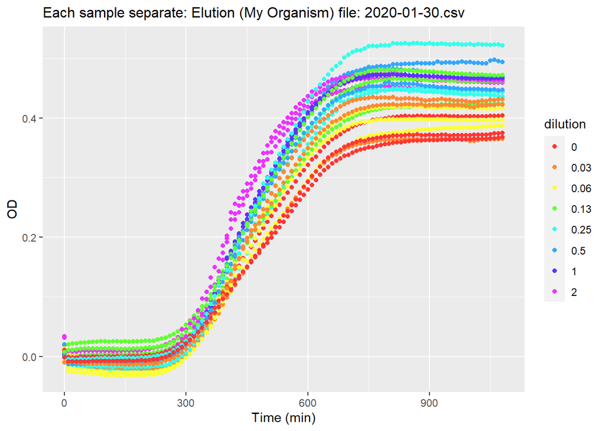

# Growthcurver

See this link: [growthcurver](https://cran.r-project.org/web/packages/growthcurver/vignettes/Growthcurver-vignette.html) On Github: [Growthcurver](https://github.com/cran/growthcurver)

## data transformat for growthcurver

```r
library(growthcurver)
# First spread the tidy data as growthcurver uses a plate setup:
spread_data <- function(df, value_to_spread){
  gc_df <-  df[, c(1, 2, 4)] %>% spread(key = "dilution", value = value_to_spread)
  colnames(gc_df)[1] <- "time"
  gc_df$time <- gc_df$time / 60
  return(gc_df)
}

gc_df_s1 <- spread_data(stat.sample1, value_to_spread = "OD_N") #growth curver data frame sample 1
gc_df_s2 <- spread_data(stat.sample2, value_to_spread = "OD_N") #growth curver data frame sample 2
gc_df_s3 <- spread_data(stat.sample3, value_to_spread = "OD_N") #growth curver data frame sample 3

# Replace negative values with zeros. This is done because of modeling problems
gc_df_s1[2:9] <- replace(gc_df_s1[2:9], gc_df_s1[2:9] < 0, 0)
gc_df_s2[2:9] <- replace(gc_df_s2[2:9], gc_df_s2[2:9] < 0, 0)
gc_df_s3[2:9] <- replace(gc_df_s3[2:9], gc_df_s3[2:9] < 0, 0)
tail(gc_df_s3)
```

```
##         time         0      0.03      0.06      0.13      0.25       0.5
## 104 17.16667 0.3799525 0.4045491 0.3993510 0.4526171 0.4694043 0.4705123
## 105 17.33333 0.3802440 0.4040409 0.3991193 0.4525428 0.4692647 0.4703570
## 106 17.50000 0.3808244 0.4055506 0.3997953 0.4523214 0.4683567 0.4711514
## 107 17.66667 0.3812879 0.4051780 0.3993010 0.4522843 0.4688970 0.4721492
## 108 17.83333 0.3816751 0.4061010 0.3998700 0.4522395 0.4680837 0.4706623
## 109 18.00000 0.3824154 0.4063147 0.4001113 0.4523570 0.4671840 0.4703053
##             1         2
## 104 0.4662328 0.4568349
## 105 0.4656448 0.4565497
## 106 0.4654829 0.4566067
## 107 0.4655394 0.4558975
## 108 0.4652921 0.4562348
## 109 0.4651321 0.4562428
```

## Single selection

```r
column_selector <- 2 # select a dilution. 1 is time and not a dilution!
gc_fit <- SummarizeGrowth(gc_df_s1$time, gc_df_s1[[column_selector]], bg_correct = "none")
gc_fit
```

```
## Fit data to K / (1 + ((K - N0) / N0) * exp(-r * t)):
##      K   N0  r
##   val:   0.45    0.002   0.693
##   Residual standard error: 0.005490798 on 106 degrees of freedom
##
## Other useful metrics:
##   DT 1 / DT  auc_l   auc_e
##   1  1e+00   4.49    4.51
```

## Plot single curve

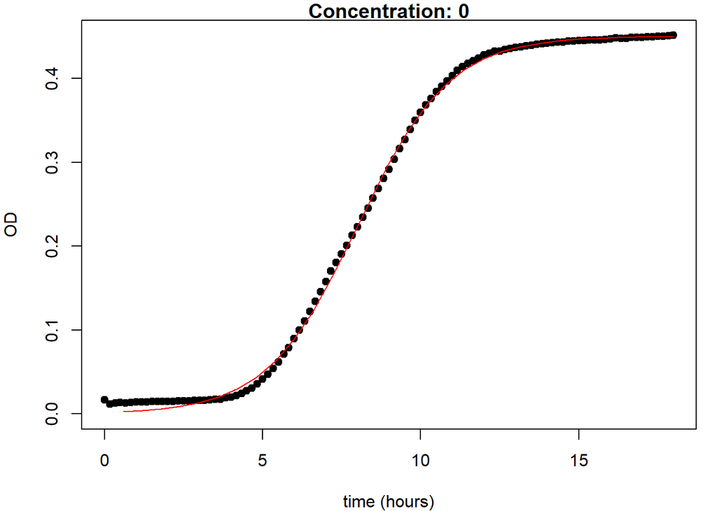

```r
plot(gc_fit, ylab = "OD", xlab = "time (hours)", main = paste("Concentration:", colnames(gc_df_s1)[column_selector], sep = " "))
```

## Properties of the gcfit object returned from the SummarizeGrowth function:

The gcfit object returned from SummarizeGrowth also contains further metrics summarizing the growth curve data. Explanation on object: - k: The carrying capacity parameter - k_se: The standard error of the carrying capacity parameter - k_p: The p value of the carrying capacity parameter - n0: The initial population size - n0_se: The standard error of the initial population size - n0_p: The p value of the initial population size - r: The growth rate - r_se: The standard error of the growth rate - r_p: The p value of the growthrate - sigma: Residual standard error from non-linear least squares fit of the model to the data - df: Degrees of freedom - t_mid: The time at the inflection point of the logistic curve (occurs at half of the carrying capacity) - dt: The maximum doubling time, obtained by evaluating the the unrestrained growth of the population with growth rate r - auc_l: The area under the curve of the fitted logistic equation from time 0 to time t - auc_e: The area under the curve of the measurements. - note: Feedback on common problems with fitting the logistic curve to the data

```r
paste("Concentration:", colnames(gc_df_s1)[column_selector], sep = " ")
```

```
## [1] "Concentration: 0"
```

```r
str(gc_fit$vals)
```

```
## List of 16
##  $ k    : num 0.45
##  $ k_se : num 0.00102
##  $ k_p  : num 6.32e-175
##  $ n0   : num 0.00173
##  $ n0_se: num 9.71e-05
##  $ n0_p : num 1.06e-33
##  $ r    : num 0.693
##  $ r_se : num 0.00717
##  $ r_p  : num 3.28e-105
##  $ sigma: num 0.00549
##  $ df   : num 106
##  $ t_mid: num 8.02
##  $ t_gen: num 1
##  $ auc_l: num 4.49
##  $ auc_e: num 4.51
##  $ note : chr ""
##  - attr(*, "class")= chr "gcvals"
```

## Get them all

#### Sample 1

```r
gc_out_s1 <- SummarizeGrowthByPlate(gc_df_s1, plot_fit = TRUE,
                                 plot_file = "./plots/gc_plots_s1.pdf", bg_correct = "none")
gc_out_s1
```

```
##   sample          k           n0         r     t_mid     t_gen     auc_l
## 1      0 0.45031593 1.731561e-03 0.6932012  8.016538 0.9999221 4.4938504
## 2   0.03 0.34515303 9.053702e-04 0.6353066  9.351033 1.0910436 2.9860177
## 3   0.06 0.15586771 7.107603e-08 0.9526793 15.326005 0.7275766 0.4291203
## 4   0.13 0.00000000 0.000000e+00 0.0000000  0.000000 0.0000000 0.0000000
## 5   0.25 0.00000000 0.000000e+00 0.0000000  0.000000 0.0000000 0.0000000
## 6    0.5 0.04217215 2.886662e-02 2.0839395 -0.371655 0.3326139 0.7514274
## 7      1 0.00000000 0.000000e+00 0.0000000  0.000000 0.0000000 0.0000000
## 8      2 0.00000000 0.000000e+00 0.0000000  0.000000 0.0000000 0.0000000
##       auc_e       sigma             note
## 1 4.5113008 0.005490798
## 2 2.9687551 0.004728850
## 3 0.4255070 0.001111342
## 4 0.0000000 0.000000000  cannot fit data
## 5 0.0000000 0.000000000  cannot fit data
## 6 0.7512097 0.001063744 questionable fit
## 7 0.0000000 0.000000000  cannot fit data
## 8 0.0000000 0.000000000  cannot fit data
```

```r
#View(gc_out_s1)
```

### Sample 2

```r
gc_out_s2 <- SummarizeGrowthByPlate(gc_df_s2, plot_fit = TRUE,
                                 plot_file = "./plots/gc_plots_s2.pdf", bg_correct = "none")
gc_out_s2
```

```
##   sample          k           n0         r      t_mid     t_gen      auc_l
## 1      0 0.45186822 1.840303e-03 0.6955943  7.9060164 0.9964820 4.55907900
## 2   0.03 0.39894472 1.717218e-03 0.6151600  8.8494118 1.1267755 3.65010652
## 3   0.06 0.36545580 1.066650e-03 0.6853769  8.5116667 1.0113372 3.46680650
## 4   0.13 0.38408684 1.011511e-03 0.6523311  9.1008788 1.0625696 3.41825341
## 5   0.25 0.27113446 4.250884e-05 0.6617341 13.2387025 1.0474708 1.30806775
## 6    0.5 0.02621654 3.832378e-04 0.2895090 14.5445008 2.3942163 0.11761547
## 7      1 0.00000000 0.000000e+00 0.0000000  0.0000000 0.0000000 0.00000000
## 8      2 0.00460930 1.756260e-02 0.7855630 -0.3875196 0.8823572 0.09081634
##        auc_e        sigma                      note
## 1 4.57113118 0.0055467289
## 2 3.60403206 0.0100772169
## 3 3.43353959 0.0074040968
## 4 3.42721355 0.0045355314
## 5 1.33304995 0.0027480842
## 6 0.11563216 0.0004788082
## 7 0.00000000 0.0000000000           cannot fit data
## 8 0.08857592 0.0006653270 questionable fit (k < n0)
```

```r
#View(gc_out_s2)
```

### Sample 3

```r
gc_out_s3 <- SummarizeGrowthByPlate(gc_df_s3, plot_fit = TRUE,
                                 plot_file = "./plots/gc_plots_s3.pdf", bg_correct = "none")
gc_out_s3
```

```
##   sample         k           n0         r    t_mid     t_gen    auc_l    auc_e
## 1      0 0.3816366 0.0009644466 0.7356650 8.126171 0.9422049 3.767265 3.739410
## 2   0.03 0.4065738 0.0004448648 0.8566809 7.957054 0.8091078 4.082766 4.052445
## 3   0.06 0.3988106 0.0004819263 0.8389215 8.006996 0.8262360 3.984850 3.949245
## 4   0.13 0.4572953 0.0015343622 0.7279822 7.821418 0.9521485 4.652886 4.664033
## 5   0.25 0.4729436 0.0005082627 0.8481713 8.058110 0.8172254 4.701475 4.665797
## 6    0.5 0.4749983 0.0006421220 0.8400196 7.862835 0.8251559 4.814484 4.778322
## 7      1 0.4700130 0.0005393007 0.8827234 7.668420 0.7852371 4.855423 4.820181
## 8      2 0.4596835 0.0004099188 0.9857400 7.123016 0.7031744 4.999564 4.977735
##         sigma note
## 1 0.006590168
## 2 0.007722719
## 3 0.008863554
## 4 0.006536235
## 5 0.009403707
## 6 0.009698369
## 7 0.009809971
## 8 0.008446531
```

```r
#View(gc_out_s3)
```

## Without backgroud correction

```r
vars <- c("dilution", "timepoint")
sample1_no_corr <- summarySE(df_tidy_s1, measurevar="OD_S", groupvars=vars)
sample2_no_corr <- summarySE(df_tidy_s2, measurevar="OD_S", groupvars=vars)
sample3_no_corr <- summarySE(df_tidy_s3, measurevar="OD_S", groupvars=vars)


gc_df_no_corr_s1 <- spread_data(sample1_no_corr, value_to_spread = "OD_S")
gc_df_no_corr_s2 <- spread_data(sample2_no_corr, value_to_spread = "OD_S")
gc_df_no_corr_s3 <- spread_data(sample3_no_corr, value_to_spread = "OD_S")
#gc_df_no_corr_s1
```

### Sample 1 (no correction)

```r
gc_out_no_corr_s1 <- SummarizeGrowthByPlate(gc_df_no_corr_s1, plot_fit = TRUE,
                                 plot_file = "./plots/gc_plots_no_corr_s1.pdf", bg_correct = "none")
gc_out_no_corr_s1
```

```
##   sample            k         n0          r       t_mid     t_gen    auc_l
## 1      0 5.531391e-01 0.02527773 0.41228338    7.370925  1.681240 5.833264
## 2   0.03 5.276195e-01 0.05259196 0.25324152    8.690556  2.737099 4.881498
## 3   0.06 2.234260e+06 0.08677197 0.05332970  319.969784 12.997395 2.622089
## 4   0.13 1.357717e-01 0.13658751 0.01596174 -320.798069 43.425548 2.456644
## 5   0.25 1.494290e-01 0.15098961 0.01767991 -258.606116 39.205357 2.713748
## 6    0.5 0.000000e+00 0.00000000 0.00000000    0.000000  0.000000 0.000000
## 7      1 0.000000e+00 0.00000000 0.00000000    0.000000  0.000000 0.000000
## 8      2 2.406920e-01 0.24427118 0.01073382 -393.443160 64.576026 4.390963
##      auc_e       sigma                      note
## 1 5.921732 0.028164328
## 2 4.924991 0.027551591
## 3 2.627450 0.024609415
## 4 2.451760 0.003178324 questionable fit (k < n0)
## 5 2.707383 0.003972174 questionable fit (k < n0)
## 6 0.000000 0.000000000           cannot fit data
## 7 0.000000 0.000000000           cannot fit data
## 8 4.368389 0.018560498 questionable fit (k < n0)
```

### Sample 2 (no correction)

```r
gc_out_no_corr_s2 <- SummarizeGrowthByPlate(gc_df_no_corr_s2, plot_fit = TRUE,
                                 plot_file = "./plots/gc_plots_no_corr_s2.pdf", bg_correct = "none")
gc_out_no_corr_s2
```

```
##   sample            k         n0           r       t_mid      t_gen    auc_l
## 1      0 5.463331e-01 0.02178124 0.435359870    7.307736   1.592125 5.802365
## 2   0.03 5.254446e-01 0.02936898 0.346162638    8.166073   2.002374 5.129508
## 3   0.06 5.015853e-01 0.03057070 0.355576953    7.691294   1.949359 5.117633
## 4   0.13 5.200253e-01 0.03414490 0.312413356    8.499474   2.218686 4.910900
## 5   0.25 3.078222e+06 0.05756163 0.104898268  169.638281   6.607804 3.076914
## 6    0.5 3.205973e+05 0.09744993 0.009924205 1512.096684  69.844103 1.920532
## 7      1 9.808050e-02 0.09907957 0.007514601 -611.722331  92.240057 1.782258
## 8      2 3.735256e+03 0.09780886 0.001356078 7779.999686 511.141126 1.782222
##      auc_e       sigma                      note
## 1 5.891750 0.026500055
## 2 5.184537 0.021343323
## 3 5.179118 0.023706728
## 4 4.981321 0.029057302
## 5 3.111944 0.025570407
## 6 1.917535 0.003748972
## 7 1.777608 0.003935556 questionable fit (k < n0)
## 8 1.778796 0.004107022
```

### Sample 3 (no correction)

```r
gc_out_no_corr_s3 <- SummarizeGrowthByPlate(gc_df_no_corr_s3, plot_fit = TRUE,
                                 plot_file = "./plots/gc_plots_no_corr_s3.pdf", bg_correct = "none")
gc_out_no_corr_s3
```

```
##   sample         k          n0         r    t_mid    t_gen    auc_l    auc_e
## 1      0 0.4859737 0.021490189 0.4181844 7.349222 1.657516 5.136878 5.213427
## 2   0.03 0.5250531 0.017197250 0.4730687 7.156356 1.465214 5.663077 5.765859
## 3   0.06 0.5263910 0.018945245 0.4605646 7.138710 1.504995 5.683049 5.776814
## 4   0.13 0.5587285 0.022458647 0.4430337 7.161897 1.564547 6.014137 6.111838
## 5   0.25 0.5989861 0.015461479 0.4964730 7.313056 1.396143 6.375752 6.500312
## 6    0.5 0.5776021 0.011887054 0.5325245 7.253451 1.301625 6.188216 6.309861
## 7      1 0.5680105 0.010278260 0.5638558 7.083102 1.229299 6.184652 6.310064
## 8      2 0.5474266 0.009286678 0.6147901 6.603128 1.127453 6.224522 6.358725
##        sigma note
## 1 0.02405398
## 2 0.02754184
## 3 0.02658556
## 4 0.02873744
## 5 0.02998123
## 6 0.02756445
## 7 0.02756049
## 8 0.03002455
```

# Growthcurve package

See this link: growthcurve NB: Do not confuse with the `growthcurver` package

```r
library(growthcurve)
```

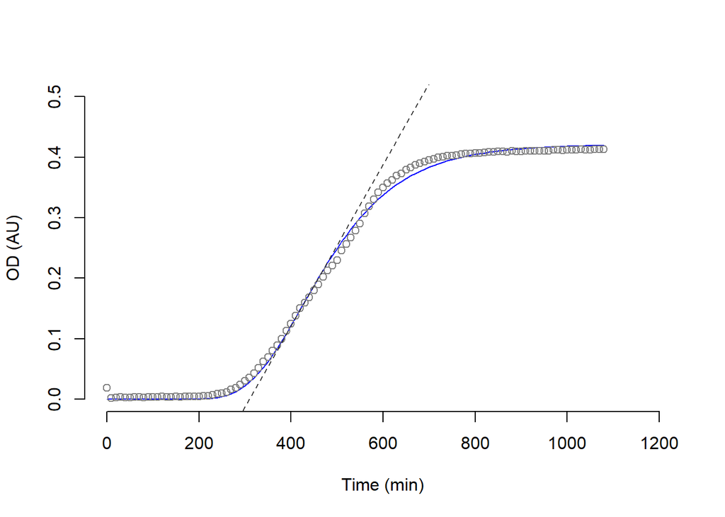

```r
rep1 <- filter(df_tidy_s1, sample == 1, dilution == 0, replicate == 1)
myfit <- fit_growth(rep1, timepoint, OD_N, model = "gompertz")
plot(myfit, show_raw = TRUE, show_maxrate = TRUE, show_asymptote = FALSE, ylab = "OD (AU)", xlab = "Time (min)")
```

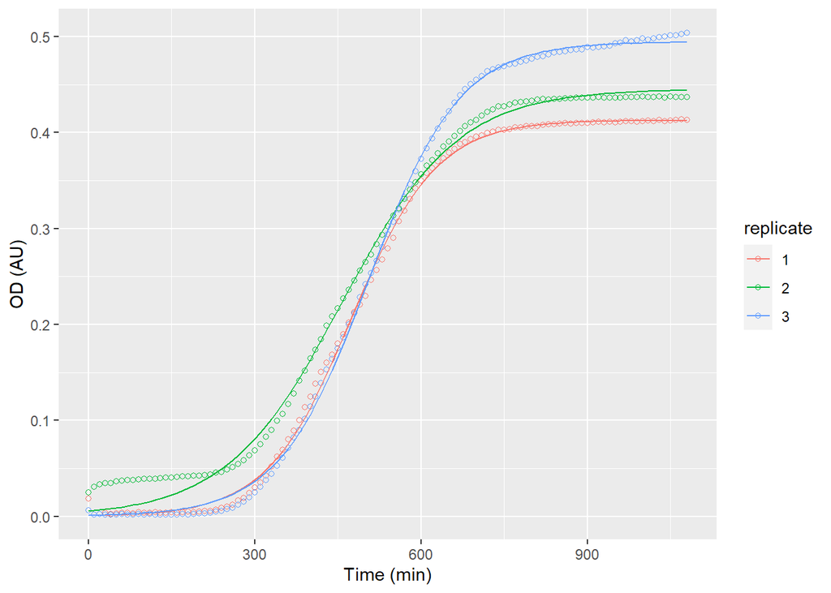

```r
test2 <- filter(df_tidy_s1, sample == 1, dilution == 0)
ggplot(data = test2, aes(x = timepoint, y = OD_N, color = replicate)) +
    geom_point(shape = 1) +
    ylab("OD (AU)") +
    xlab("Time (min)") +
    stat_growthcurve()
```

The end…